# A7 Die R-Pakete `sp` und `spdep`

Jan-Philipp Kolb

22 Oktober 2018

# Themen dieses Abschnitts

### Das erste Gesetz der Geographie (TFLG)

> “All things are related, but nearby things are more related than distant things” [Tobler, 1970]

# [Shapefile mit Regionalschlüssel](http://www.geodatenzentrum.de/geodaten/gdz_rahmen.gdz_div?gdz_spr=deu&gdz_akt_zeile=5&gdz_anz_zeile=1&gdz_unt_zeile=13&gdz_user_id=0) herunterladen

```r
library(rgdal)
setwd(vg250path)
VG250 <- readOGR ("VG250_GEM.shp","VG250_GEM")
```

# [Räumliche Stichprobe](https://www.rdocumentation.org/packages/sp/versions/1.3-1/topics/spsample)

- Mit der Funktion `spsample` aus dem Paket `sp` kann man eine räumliche Stichprobe ziehen.

```r
spatsamp <- spsample(VG250, 100,type="random")
```

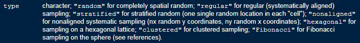

# Point in Polygon

- Mit der Funktion `over` kann man feststellen in welchem Polygon ein Punkt liegt.

```r
tmp <- sp::over(spatsamp, VG250)
```

```r
head(tmp[,1:6])
```

```
##   ADE GF BSG           RS      AGS       SDV_RS
## 1   6  4   1 150860015015 15086015 150860015015
## 2   6  4   1 097785768219 09778219 097785768219
## 3   6  4   1 130755559118 13075118 130755559118
## 4   6  4   1 120735306225 12073225 120735306225
## 5   6  4   1 033510025025 03351025 033510025025
## 6   6  4   1 082260012012 08226012 082260012012
```

# Koordinatenreferenzsystem (CRS)

### **CRS bei Wikipedia**

- Ein Koordinatenreferenzsystem ist ein Koordinatensystem, das durch Verknüpfung mit einem Datum auf die reale Welt bezogen ist.
- EPSG-Codes sind ein weit verbreitetes Mittel, um den räumlichen Bezug von Geodaten eindeutig anzugeben.
- Die 4- bis 5-stelligen Schlüsselnummern beinhalten jeweils eine komplette Beschreibung eines Koordinatenreferenzsystems.
- Es gibt mehrere hundert solcher Referenzsysteme, und jedes besteht aus einer Liste von 10 bis 20 Parametern.

# Daten in ein anderes CRS übertragen

> spTransform for map projection and datum transformation

```r
newData<-sp::spTransform(spatsamp, CRS("+init=epsg:3857"))
```

```r
head(spatsamp)
```

```
## SpatialPoints:
##             x       y
## [1,] 702452.3 5796030
## [2,] 586671.4 5308170
## [3,] 817903.3 5950479
## [4,] 830926.5 5906283
## [5,] 580863.1 5839721
## [6,] 477882.7 5478249
## Coordinate Reference System (CRS) arguments: +proj=utm +zone=32
## +ellps=GRS80 +units=m +no_defs
```

```r
head(newData)
```

```
## SpatialPoints:
##              x       y
## [1,] 1332241.6 6850421
## [2,] 1131019.7 6093720
## [3,] 1536908.3 7095969
## [4,] 1553580.4 7020564
## [5,] 1135092.4 6927946
## [6,]  967902.4 6352677
## Coordinate Reference System (CRS) arguments: +init=epsg:3857
## +proj=merc +a=6378137 +b=6378137 +lat_ts=0.0 +lon_0=0.0 +x_0=0.0
## +y_0=0 +k=1.0 +units=m +nadgrids=@null +no_defs
```

# Eine Karte von Afrika

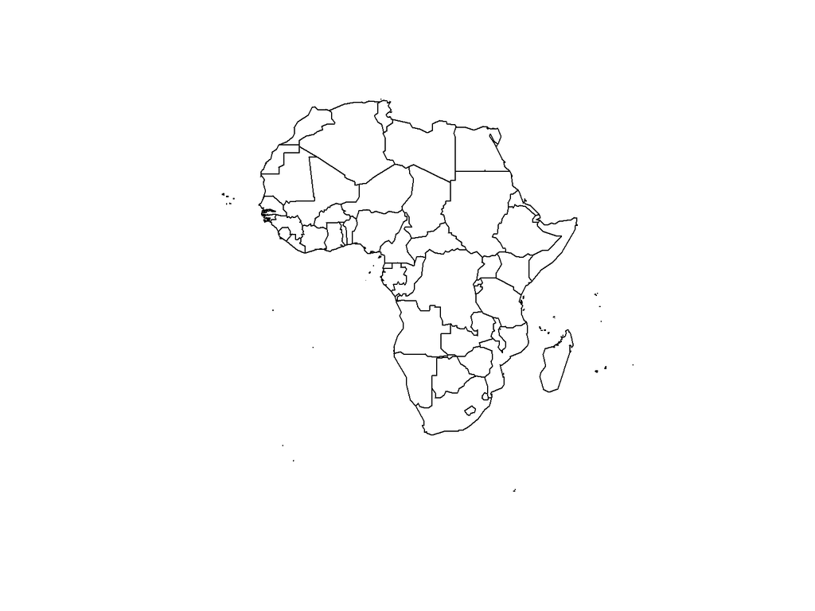

```r
library(maptools)
data(wrld_simpl)
Africa <- wrld_simpl[wrld_simpl@data$REGION==2,]
plot(Africa)
```

# Das Zentrum eines Polygonzuges

```r
Af <- coordinates(Africa)
head(Af)
```

```
##          [,1]        [,2]
## DZA  2.627813  28.1721102
## AGO 17.552463 -12.3503789
## BEN  2.332296   9.6047655
## COG 15.218362  -0.8732659
## COD 23.646032  -2.8711605
## BDI 29.901786  -3.3461606
```

# Die Koordinaten plotten

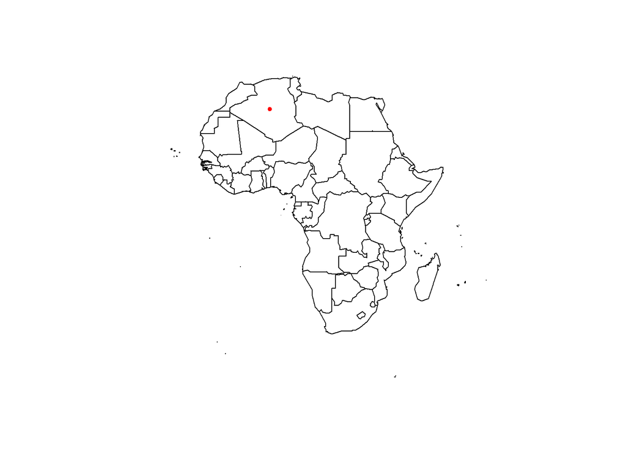

```r
plot(Africa)
points(x=Af[1,1],y=Af[1,2],col="red",pch=20)
```

# Die nächsten Nachbarn finden

```r
library(spdep)
Af_nb <- tri2nb(Af)
```

Die Nachbarn für das erste Land (Algerien):

```r
Af_nb[1]
```

```
## [[1]]
## [1] 24 26 27 32 48
```

```r
Africa@data[Af_nb[[1]],1:5]
```

```
##     FIPS ISO2 ISO3  UN                   NAME
## LBY   LY   LY  LBY 434 Libyan Arab Jamahiriya
## MLI   ML   ML  MLI 466                   Mali
## MAR   MO   MA  MAR 504                Morocco
## NER   NG   NE  NER 562                  Niger
## TUN   TS   TN  TUN 788                Tunisia
```

# Die Nachbarn finden

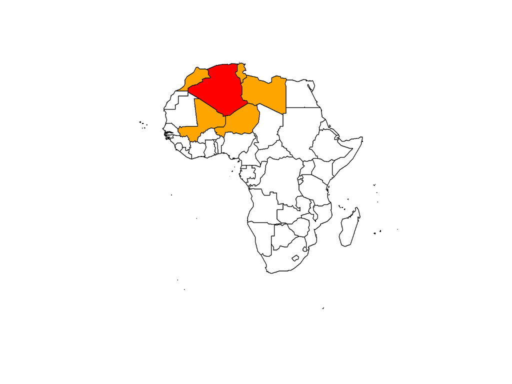

```r
plot(Africa)
plot(Africa[1,],col="red",add=T)
plot(Africa[Af_nb[1][[1]],],col="orange",add=T)
```

# *k nearest neighbours*

```r
IDs <- row.names(as(Africa, "data.frame"))
(Af10_nb <- knn2nb(knearneigh(Af, k = 10), row.names = IDs))
```

```
## Neighbour list object:
## Number of regions: 57
## Number of nonzero links: 570
## Percentage nonzero weights: 17.54386
## Average number of links: 10
## Non-symmetric neighbours list
```

# Die 10 nächsten Nachbarn finden

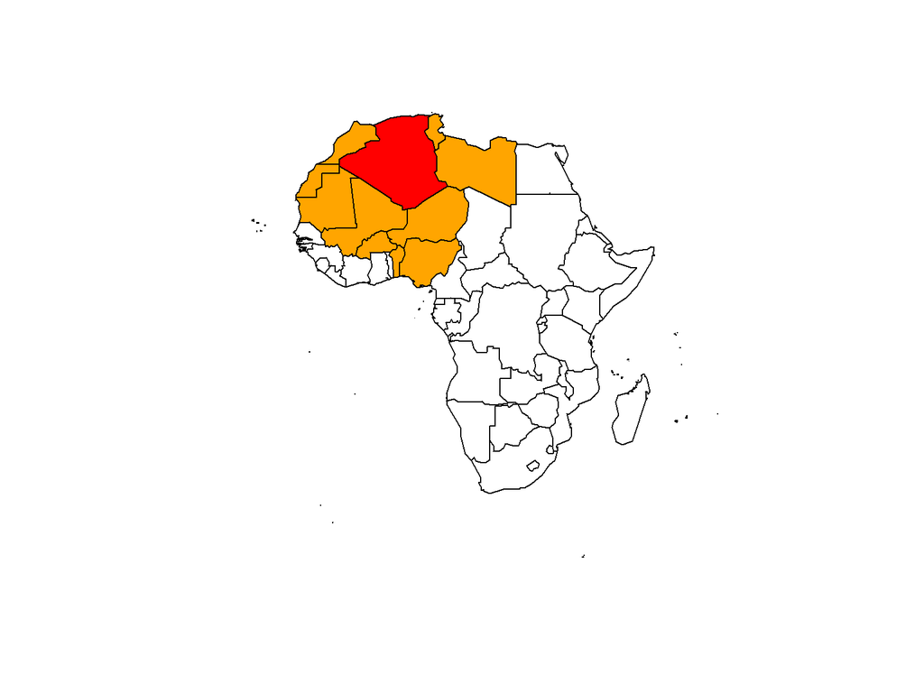

```r
plot(Africa)
plot(Africa[1,],col="red",add=T)
plot(Africa[Af10_nb[1][[1]],],col="orange",add=T)
```

# Die Distanz berechnen

```r
Af <- coordinates(Africa) # get centroid
library(raster)
pointDistance(Af[1:4,], lonlat=TRUE) # compute distance
```

```
##         [,1]    [,2]    [,3] [,4]
## [1,]       0      NA      NA   NA
## [2,] 4763231       0      NA   NA
## [3,] 2055609 2954497       0   NA
## [4,] 3484053 1295173 1839191    0
```

# Berechnen/zeichnen einer Distanzmatrix

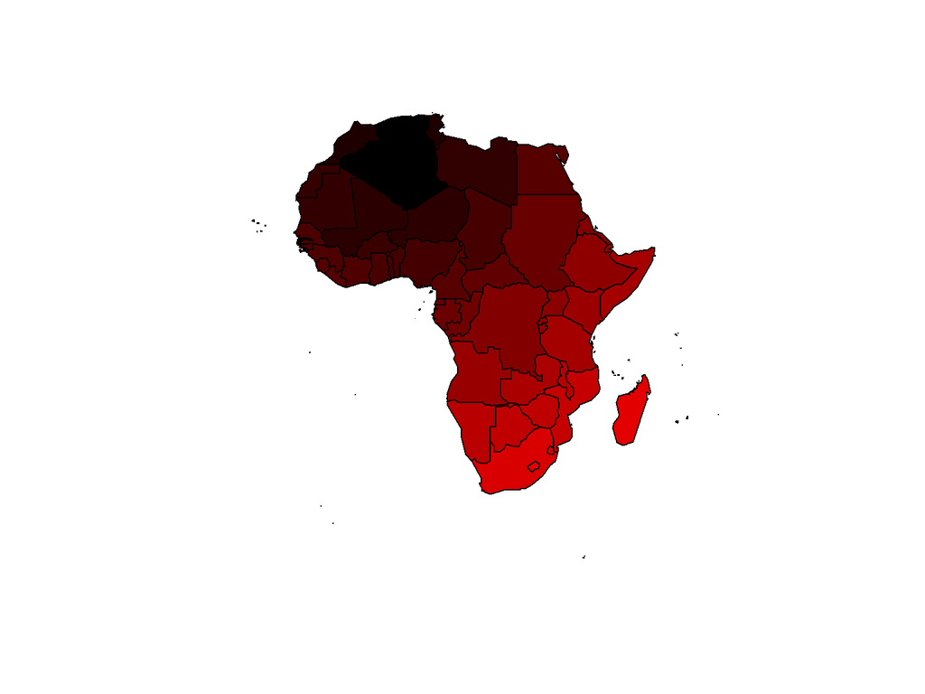

```r
Dist_Af <- pointDistance(Af, lonlat=TRUE)
Af_color <- Dist_Af[,1]
Af_color <- Af_color/max(Af_color)
Af_color <- rgb(Af_color,0,0)
plot(Africa,col=Af_color)
```

# A7A Übung - Nachbarschaften in London

- Lade den Datensatz london_sport von meinem Github Verzeichnis herunter.
- Importiere den Datensatz.
- Bestimme die nächsten Nachbarn des Stadtteils *City of London*

```r
setwd("D:/github/geocourse/data/")
london_sport <- readOGR ("london_sport.shp","london_sport")
```

# Links

- [**Raster, CMSAF and solaR**](https://procomun.wordpress.com/2011/06/17/raster-cmsaf-and-solar/)

https://procomun.wordpress.com/2011/06/17/raster-cmsaf-and-solar/

- [**Getting rasters into shape from R**](https://johnbaumgartner.wordpress.com/2012/07/26/getting-rasters-into-shape-from-r/)

https://johnbaumgartner.wordpress.com/2012/07/26/getting-rasters-into-shape-from-r/